# R-Lab: Ensemble Learning

A single decision tree (rpart), random forests, and AdaBoost are applied to ADNI_baseline2. First we change the percentage of training data and 50 replicates of data are generated. The boxplots of the classification error rates for single decision tree (rpart), random forests and AdaBoost are plotted at different percentages of training data. It can be seen, all error rates are reduced as the percentage of the training data increases. The single decision tree is clearly less accurate than the other two ensemble methods. RF has lower error rates than AdaBoost in general. However, as the training data size increases, the gap between RF and AdaBoost seems to decrease. This may indicates that when the training data size is small, RF is more stable due to its advantage of addressing the statistical issue.

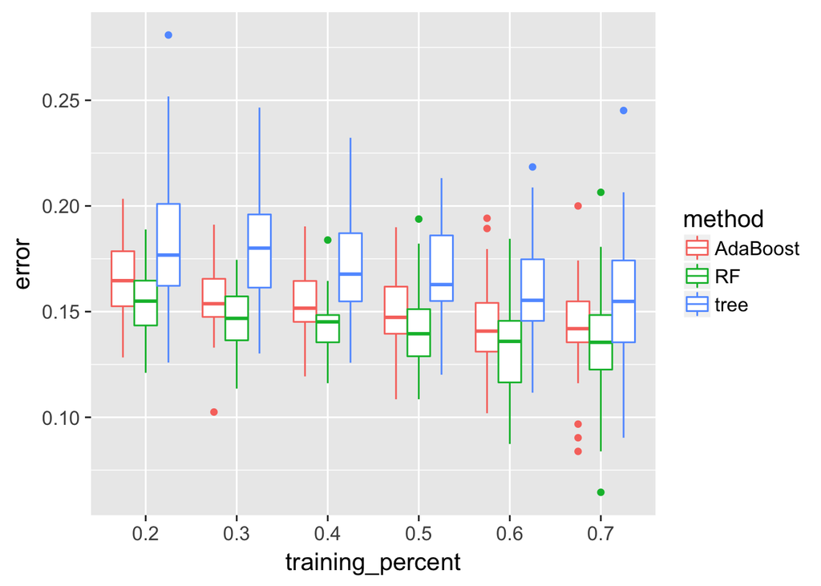

```r
library(dplyr)
library(tidyr)
library(ggplot2)
library(randomForest)
library(RCurl)
library(gbm)
library(rpart)
set.seed(1)

theme_set(theme_gray(base_size = 15))

data <- read.csv(text = getURL("https://raw.githubusercontent.com/shuailab/ind_498/master/resource/data/AD.csv"))

rm_indx <- which(colnames(data) %in% c("ID", "TOTAL13", "MMSCORE"))
data <- data[, -rm_indx]
data$DX_bl <- as.factor(data$DX_bl)
# target_indx <- which( colnames(data) == 'DX_bl' ) target <-
# data[,target_indx] rm_indx <- which( colnames(data) %in%
# c('DX_bl','ID','TOTAL13','MMSCORE') ) X <- data X <- X[,-rm_indx]

set.seed(1)

err.mat <- NULL
for (K in c(0.2, 0.3, 0.4, 0.5, 0.6, 0.7)) {

    testing.indices <- NULL
    for (i in 1:50) {
        testing.indices <- rbind(testing.indices, sample(nrow(data), floor((1 -
            K) * nrow(data))))
    }

    for (i in 1:nrow(testing.indices)) {

        testing.ix <- testing.indices[i, ]
        target.testing <- data$DX_bl[testing.ix]

        tree <- rpart(DX_bl ~ ., data[-testing.ix, ])
        pred <- predict(tree, data[testing.ix, ], type = "class")
        error <- length(which(as.character(pred) != target.testing))/length(target.testing)
        err.mat <- rbind(err.mat, c("tree", K, error))

        rf <- randomForest(DX_bl ~ ., data[-testing.ix, ])
        pred <- predict(rf, data[testing.ix, ])
        error <- length(which(as.character(pred) != target.testing))/length(target.testing)
        err.mat <- rbind(err.mat, c("RF", K, error))

        data1 <- data
        data1$DX_bl <- as.numeric(as.character(data1$DX_bl))
        boost <- gbm(DX_bl ~ ., data = data1[-testing.ix, ], dist = "adaboost",
            interaction.depth = 6, n.tree = 2000)  #cv.folds = 5,
        # best.iter <- gbm.perf(boost,method='cv')
        pred <- predict(boost, data1[testing.ix, ], n.tree = 2000, type = "response")  # best.iter n.tree = 400,
        pred[pred > 0.5] <- 1
        pred[pred <= 0.5] <- 0
        error <- length(which(as.character(pred) != target.testing))/length(target.testing)
        err.mat <- rbind(err.mat, c("AdaBoost", K, error))
    }
}
err.mat <- as.data.frame(err.mat)
colnames(err.mat) <- c("method", "training_percent", "error")
err.mat <- err.mat %>% mutate(training_percent = as.numeric(as.character(training_percent)),
    error = as.numeric(as.character(error)))

ggplot() + geom_boxplot(data = err.mat %>% mutate(training_percent = as.factor(training_percent)),
    aes(y = error, x = training_percent, color = method)) + geom_point(size = 3)
```

Now we add complexity to each classifier.

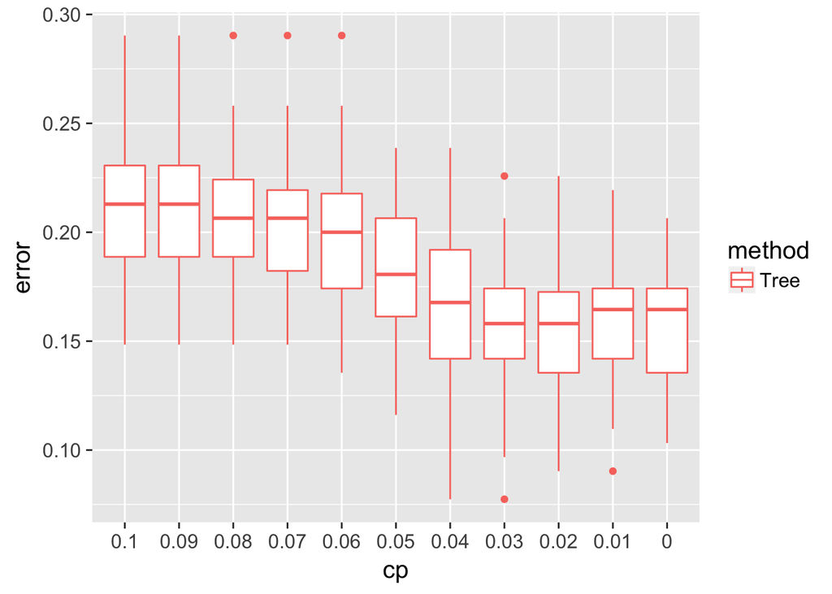

```r
set.seed(1)
testing.indices <- NULL
for (i in 1:50) {
    testing.indices <- rbind(testing.indices, sample(nrow(data), floor((0.3) *
        nrow(data))))
}


err.mat <- NULL
for (i in 1:nrow(testing.indices)) {
    testing.ix <- testing.indices[i, ]
    target.testing <- data$DX_bl[testing.ix]

    cp.v <- rev(c(0, 0.01, 0.02, 0.03, 0.04, 0.05, 0.06, 0.07, 0.08, 0.09, 0.1))
    for (j in cp.v) {
        tree <- rpart(DX_bl ~ ., data[-testing.ix, ], cp = j)
        pred <- predict(tree, data[testing.ix, ], type = "class")
        error <- length(which(as.character(pred) != target.testing))/length(target.testing)
        err.mat <- rbind(err.mat, c("Tree", j, error))
    }
}

err.mat <- as.data.frame(err.mat)
colnames(err.mat) <- c("method", "cp", "error")
err.mat <- err.mat %>% mutate(cp = as.numeric(as.character(cp)), error = as.numeric(as.character(error)))
err.mat$cp <- factor(err.mat$cp, levels = sort(cp.v, decreasing = TRUE))


ggplot() + geom_boxplot(data = err.mat, aes(y = error, x = cp, color = method)) +
    geom_point(size = 3)
```

Adjust the number of trees in AdaBoost. It can be seen that the error rates first go down and stay stable and not getting overfit.

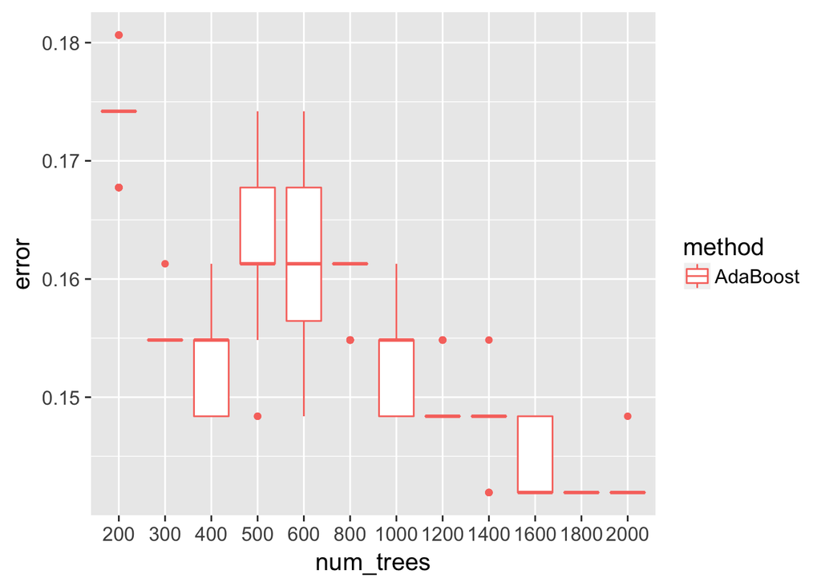

```r
err.mat <- NULL
set.seed(1)
for (i in 1:nrow(testing.indices)) {
    data1 <- data
    data1$DX_bl <- as.numeric(as.character(data1$DX_bl))
    ntree.v <- c(200, 300, 400, 500, 600, 800, 1000, 1200, 1400, 1600, 1800,
        2000)
    for (j in ntree.v) {
        boost <- gbm(DX_bl ~ ., data = data1[-testing.ix, ], dist = "adaboost",
            interaction.depth = 6, n.tree = j)
        # best.iter <- gbm.perf(boost,method='cv')
        pred <- predict(boost, data1[testing.ix, ], n.tree = j, type = "response")
        pred[pred > 0.5] <- 1
        pred[pred <= 0.5] <- 0
        error <- length(which(as.character(pred) != target.testing))/length(target.testing)
        err.mat <- rbind(err.mat, c("AdaBoost", j, error))
    }
}
err.mat <- as.data.frame(err.mat)
colnames(err.mat) <- c("method", "num_trees", "error")
err.mat <- err.mat %>% mutate(num_trees = as.numeric(as.character(num_trees)),
    error = as.numeric(as.character(error)))

ggplot() + geom_boxplot(data = err.mat %>% mutate(num_trees = as.factor(num_trees)),
    aes(y = error, x = num_trees, color = method)) + geom_point(size = 3)
```

Now look at random forests with different number of trees. Similar to AdaBoost, RF has high error rates initially at a small number of trees, but then are reduced as more trees are added. Overfitting did not occur as at a large number of trees.

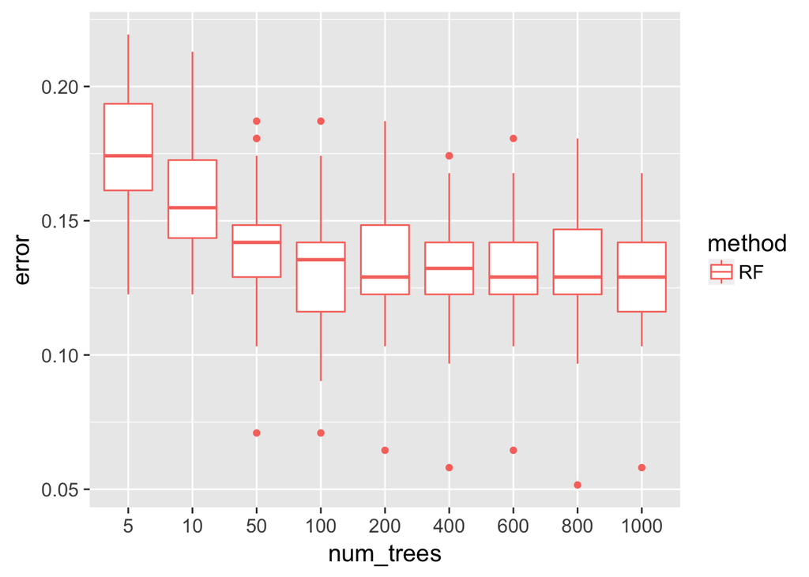

```r
err.mat <- NULL
set.seed(1)
for (i in 1:nrow(testing.indices)) {
    testing.ix <- testing.indices[i, ]
    target.testing <- data$DX_bl[testing.ix]

    ntree.v <- c(5, 10, 50, 100, 200, 400, 600, 800, 1000)
    for (j in ntree.v) {
        rf <- randomForest(DX_bl ~ ., data[-testing.ix, ], ntree = j)
        pred <- predict(rf, data[testing.ix, ])
        error <- length(which(as.character(pred) != target.testing))/length(target.testing)
        err.mat <- rbind(err.mat, c("RF", j, error))
    }
}
err.mat <- as.data.frame(err.mat)
colnames(err.mat) <- c("method", "num_trees", "error")
err.mat <- err.mat %>% mutate(num_trees = as.numeric(as.character(num_trees)),
    error = as.numeric(as.character(error)))

ggplot() + geom_boxplot(data = err.mat %>% mutate(num_trees = as.factor(num_trees)),
    aes(y = error, x = num_trees, color = method)) + geom_point(size = 3)
```

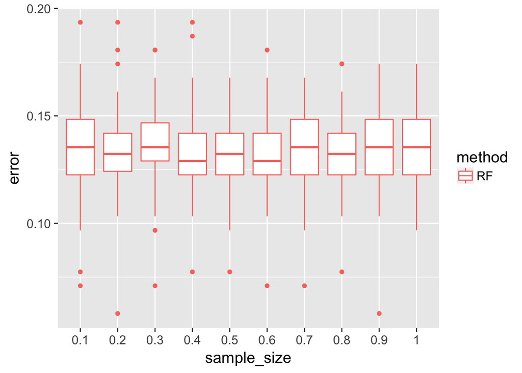

```r
err.mat <- NULL
set.seed(1)
for (i in 1:nrow(testing.indices)) {
    testing.ix <- testing.indices[i, ]
    target.testing <- data$DX_bl[testing.ix]

    sample.size.v <- seq(0.1, 1, by = 0.1)
    for (j in sample.size.v) {
        sample.size <- floor(nrow(data[-testing.ix, ]) * j)
        rf <- randomForest(DX_bl ~ ., data[-testing.ix, ], sampsize = sample.size,
            replace = FALSE)
        pred <- predict(rf, data[testing.ix, ])
        error <- length(which(as.character(pred) != target.testing))/length(target.testing)
        err.mat <- rbind(err.mat, c("RF", j, error))
    }
}
err.mat <- as.data.frame(err.mat)
colnames(err.mat) <- c("method", "sample_size", "error")
err.mat <- err.mat %>% mutate(sample_size = as.numeric(as.character(sample_size)),
    error = as.numeric(as.character(error)))

ggplot() + geom_boxplot(data = err.mat %>% mutate(sample_size = as.factor(sample_size)),
    aes(y = error, x = sample_size, color = method)) + geom_point(size = 3)
```

Now we change the randomness in the features tested in a tree node. From using one feature to all features.

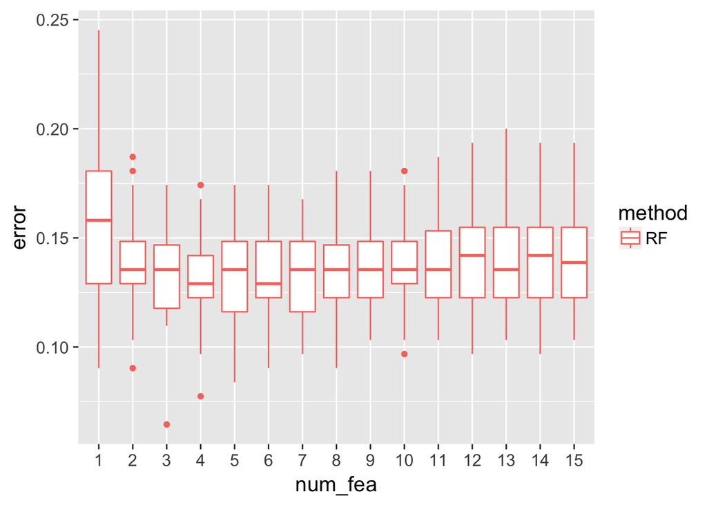

```r
err.mat <- NULL
set.seed(1)
for (i in 1:nrow(testing.indices)) {
    testing.ix <- testing.indices[i, ]
    target.testing <- data$DX_bl[testing.ix]

    num.fea.v <- 1:(ncol(data) - 1)
    for (j in num.fea.v) {
        rf <- randomForest(DX_bl ~ ., data[-testing.ix, ], mtry = j)
        pred <- predict(rf, data[testing.ix, ])
        error <- length(which(as.character(pred) != target.testing))/length(target.testing)
        err.mat <- rbind(err.mat, c("RF", j, error))
    }
}
err.mat <- as.data.frame(err.mat)
colnames(err.mat) <- c("method", "num_fea", "error")
err.mat <- err.mat %>% mutate(num_fea = as.numeric(as.character(num_fea)), error = as.numeric(as.character(error)))

ggplot() + geom_boxplot(data = err.mat %>% mutate(num_fea = as.factor(num_fea)),
    aes(y = error, x = num_fea, color = method)) + geom_point(size = 3)
```

Now let’s use all samples and change the number of features.

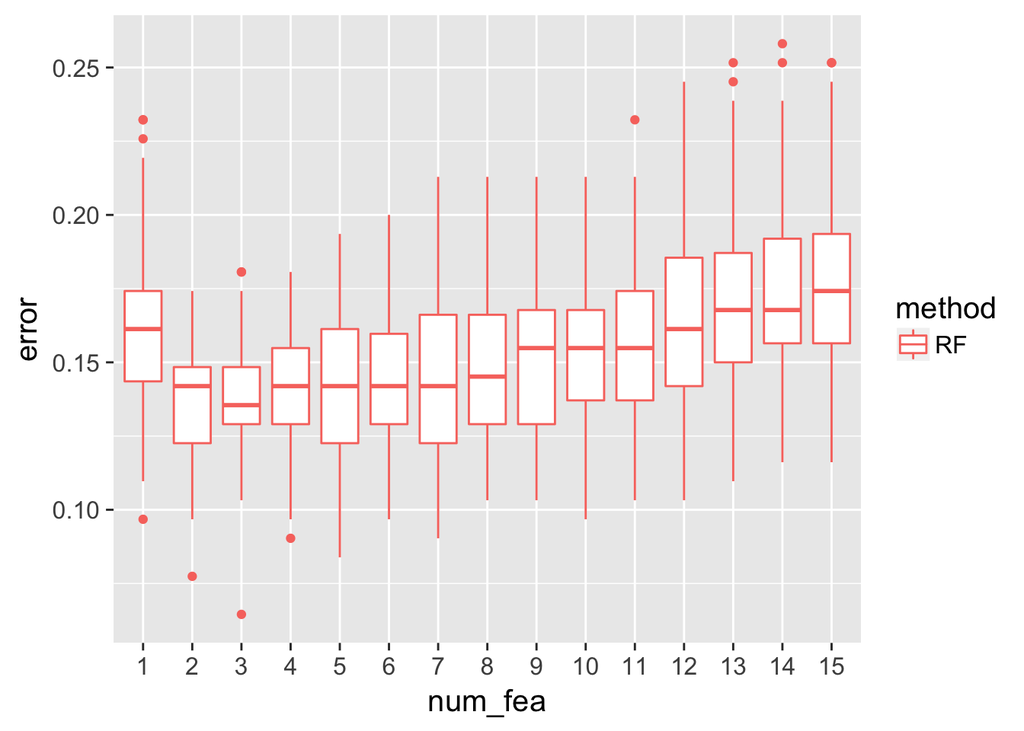

```r
err.mat <- NULL
set.seed(1)
for (i in 1:nrow(testing.indices)) {
    testing.ix <- testing.indices[i, ]
    target.testing <- data$DX_bl[testing.ix]

    num.fea.v <- 1:(ncol(data) - 1)
    for (j in num.fea.v) {
        sample.size <- nrow(data[-testing.ix, ])
        rf <- randomForest(DX_bl ~ ., data[-testing.ix, ], mtry = j, sampsize = sample.size,
            replace = FALSE)
        pred <- predict(rf, data[testing.ix, ])
        error <- length(which(as.character(pred) != target.testing))/length(target.testing)
        err.mat <- rbind(err.mat, c("RF", j, error))
    }
}
err.mat <- as.data.frame(err.mat)
colnames(err.mat) <- c("method", "num_fea", "error")
err.mat <- err.mat %>% mutate(num_fea = as.numeric(as.character(num_fea)), error = as.numeric(as.character(error)))

ggplot() + geom_boxplot(data = err.mat %>% mutate(num_fea = as.factor(num_fea)),
    aes(y = error, x = num_fea, color = method)) + geom_point(size = 3)
```

Also change the number of samples selected for each tree using all features.

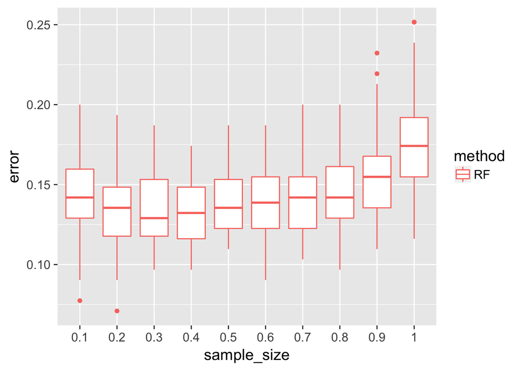

```r
err.mat <- NULL
set.seed(1)
for (i in 1:nrow(testing.indices)) {
    testing.ix <- testing.indices[i, ]
    target.testing <- data$DX_bl[testing.ix]

    sample.size.v <- seq(0.1, 1, by = 0.1)
    for (j in sample.size.v) {
        traing.data <- data[-testing.ix, ]
        sample.size <- floor(nrow(traing.data) * j)
        rf <- randomForest(DX_bl ~ ., traing.data, mtry = ncol(traing.data) -
            1, sampsize = sample.size, replace = FALSE)
        pred <- predict(rf, data[testing.ix, ])
        error <- length(which(as.character(pred) != target.testing))/length(target.testing)
        err.mat <- rbind(err.mat, c("RF", j, error))
    }
}
err.mat <- as.data.frame(err.mat)
colnames(err.mat) <- c("method", "sample_size", "error")
err.mat <- err.mat %>% mutate(sample_size = as.numeric(as.character(sample_size)),
    error = as.numeric(as.character(error)))

ggplot() + geom_boxplot(data = err.mat %>% mutate(sample_size = as.factor(sample_size)),
    aes(y = error, x = sample_size, color = method)) + geom_point(size = 3)
```